# Mapping free school meals in York, UK. 2021

# Task

What can we learn about changes in school meal uptake in York from published free school meals data?

# Data Sources

Data Source: https://data.yorkopendata.org/dataset/free-school-meals/resource/03b0ae33-f6fe-4431-94f8-4b811c8921ba

The data is published annually by York City Council, UK.

# Data Preparation & Processing

# Analysis

Load core libraries

```r
library(tidyverse)  #helps wrangle data
library(ggplot2)  #helps visualize data
```

Load data:

```r
fsmraw <- read_csv("csv/fsmdetails.csv")
```

Remove FSMTaken column as it stops being recorded in 2018:

```r
fsmdetails <- fsmraw %>% select(-FSMTaken)
```

Create pivot table to summarise data, making visual checking easier

```r
fsmdetails %>%
  group_by(SchoolName, Year, TotalFSM) %>%
  summarise(SchoolName)
```

| SchoolName | Year | TotalFSM |
| --- | --- | --- |
| Acomb Primary School | 2014 | 14 |
| Acomb Primary School | 2015 | 7 |
| Acomb Primary School | 2016 | 8 |
| Acomb Primary School | 2017 | 10 |
| Acomb Primary School | 2018 | 16 |
| Acomb Primary School | 2019 | 24 |
| Acomb Primary School | 2020 | 30 |
| All Saints RC | 2017 | 51 |
| All Saints RC School | 2014 | 48 |
| All Saints RC School | 2015 | 45 |

[output cut: 429 more lines]

## Make school names consistent with the latest (2020)

```r
oldSchool = c(
  "All Saints RC",
  "Applefields",
  "Archbishop Holgate's CE",
  "Archbishop of York's CE Junior School",
  "Archbishop Of Yorks Ce Junior",
  "Badger Hill Primary",
  "Canon Lee",
  "Dunnington Ce Primary School",
  "Fulford",
  "Hob Moor Oaks",
  "Huntington",
  "Huntington Primary School",
  "Joseph Rowntree",
  "Lord Deramore's VC Primary School",
  "Manor CE",
  "Millthorpe",
  "Our Lady Queen of Martyrs Primary School",
  "Park Grove Primary School",
  "Robert Wilkinson Academy Primary School",
  "Robert Wilkinson Primary Academy",
  "St Aelred's RCVA Primary",
  "St Aelreds Rc Primary School",
  "St Aelreds RC Primary School",
  "St Barnabas C Of E Primary School",
  "St Barnabas CE Primary School",
  "St George's Primary School",
  "St Georges Rc Primary School",
  "St Georges RC Primary School",
  "St Lawrence's Primary School",
  "St Lawrences CE Primary School",
  "St Marys CE Primary School",
  "St Marys Ce Primary School",
  "St Oswald's Primary School",
  "St Oswalds Ce Primary School",
  "St Oswalds CE Primary School",
  "St Pauls Ce Primary School",
  "St Pauls CE Primary School",
  "St Pauls Nursery School",
  "St Wilfrid's Primary School",
  "Stockton-on-the-Forest Primary School",
  "Vale of York",
  "Westfield Primary Community School",
  "Wheldrake CE (Aided) School",
  "Wheldrake with Thorganby C.E. (Aided) School",
  "York High"
)

newSchool = c(
  "All Saints RC School",
  "Applefields School",
  "Archbishop Holgates CE School",
  "Archbishop Of Yorks CE Junior",
  "Archbishop Of Yorks CE Junior",
  "Badger Hill Primary School",
  "Canon Lee Specialist Arts College",
  "Dunnington CE Primary School",
  "Fulford School",
  "Hob Moor Oaks School",
  "Huntington School",
  "Huntington Primary Academy",
  "Joseph Rowntree School",
  "Lord Deramores Primary School",
  "Manor CE Academy",
  "Millthorpe School",
  "Our Lady Queen of Martyrs RC Primary School",
  "Park Grove Primary Academy",
  "Robert Wilkinson Primary School",
  "Robert Wilkinson Primary School",
  "St Aelred's RC Primary School",
  "St Aelred's RC Primary School",
  "St Aelred's RC Primary School",
  "St Barnabas' CE Primary School",
  "St Barnabas' CE Primary School",
  "St George's RC Primary School",
  "St George's RC Primary School",
  "St George's RC Primary School",
  "St Lawrence's CE Primary School",
  "St Lawrence's CE Primary School",
  "St Mary's CE Primary School",
  "St Mary's CE Primary School",
  "St Oswald's CE Primary School",
  "St Oswald's CE Primary School",
  "St Oswald's CE Primary School",
  "St Paul's CE Primary School",
  "St Paul's CE Primary School",
  "St Paul's Nursery School",
  "St Wilfrid's RC Primary School",
  "Stockton On The Forest Primary School",
  "Vale of York Academy",
  "Westfield Community Primary School",
  "Wheldrake with Thorganby CE Primary School",
  "Wheldrake with Thorganby CE Primary School",
  "York High School"
)

renameSchools <- cbind(oldSchool, newSchool)
for(i in 1:nrow(renameSchools)) {
  oldName = renameSchools[i,][1]
  newName  = renameSchools[i,][2]
  fsmdetails$SchoolName[fsmdetails$SchoolName == oldName] <- newName
}
```

## Replace values <5 and 9999 for 2 in TotalFSM

I have opted for 2 as a replacement value because it is the median of the value of less than 5.

```r
fsmdetails$TotalFSM[fsmdetails$TotalFSM == '9999'] <- '2'
fsmdetails$TotalFSM[fsmdetails$TotalFSM == '<5'] <- '2'
```

```r
fsmdetails$TotalFSM <- as.numeric(as.character(fsmdetails$TotalFSM))
```

## Add in new column to show TotalFSM as a percentage of TotalPupils

```r
fsmdetails$TotalFSMPercentage <- (fsmdetails$TotalFSM / fsmdetails$TotalPupils) * 100
```

## Transform data from long to wide

```r
library("reshape2")
fsmWide <- dcast(fsmdetails, SchoolName ~ Year, value.var="TotalFSMPercentage")
```

# Key findings

Calculate mean values for each year, ignoring schools with N/A

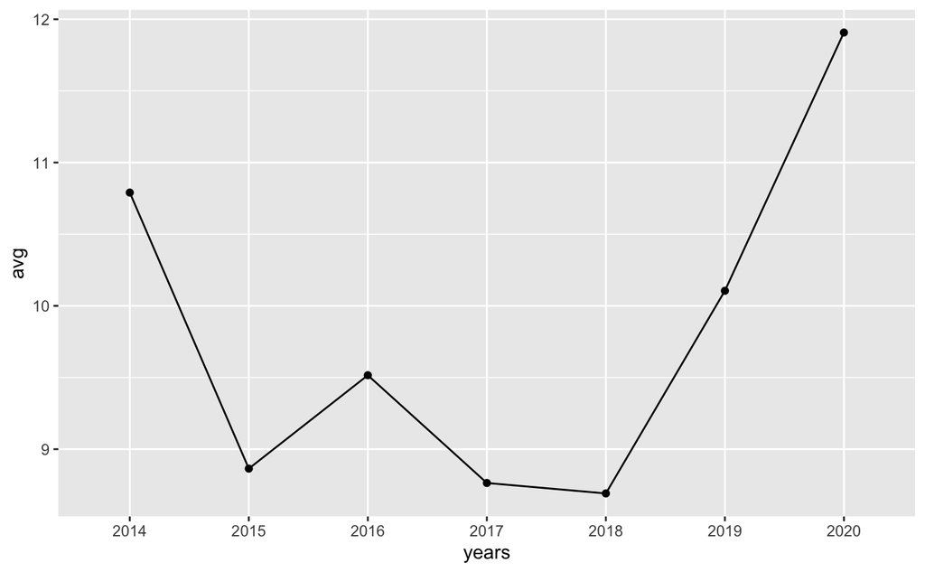

```r
# Plotting mean average percentage change
fsmWide2 <- na.omit(fsmWide)
avgPerc = c(
  mean(fsmWide2$`2014`),
  mean(fsmWide2$`2015`),
  mean(fsmWide2$`2016`),
  mean(fsmWide2$`2017`),
  mean(fsmWide2$`2018`),
  mean(fsmWide2$`2019`),
  mean(fsmWide2$`2020`)
)
avgDf <- data.frame(years=c("2014", "2015", "2016", "2017", "2018", "2019", "2020"), avg=avgPerc)
ggplot(data=avgDf, aes(x=years, y=avg, group=1)) +
  geom_line()+
  geom_point()
```

# Supporting visualisations

Multiple line plot for each school, showing trends over time

[figure not shown]

```r
ggplot(fsmdetails, aes(x = Year, y = TotalFSMPercentage)) +
  geom_line(aes(color = SchoolName), size = 1)  +
  theme_minimal() +
   xlab("Year") + ylab("Free School Meal Takeup (%)")
```

# Reflections

- The number of children taking free school meals in York has risen significantly since 2019.

# Reflections

1. Next time count school name occurances to make normalising them easier